# A toy example

2023-06-30

Suppose there is a hypothetical trial randomizing a total of 90 patients in 2:1 ratio to the treatment and standard of care (SOC) arm. Assume there is an external control with a sample size of 100. The table below summarizes the pretreatment characteristics of the internal and external control group (IC vs EC).

|  | IC (N=30) | EC (N=100) | Overall (N=130) |
| --- | --- | --- | --- |
| Sex |  |  |  |
| Male | 10 (33.3%) | 52 (52.0%) | 62 (47.7%) |
| Female | 20 (66.7%) | 48 (48.0%) | 68 (52.3%) |
| Age (years) |  |  |  |
| Mean (SD) | 58.8 (11.3) | 58.0 (8.62) | 58.2 (9.28) |
| Median [Min, Max] | 57.7 [41.4, 84.6] | 58.1 [35.7, 80.1] | 58.1 [35.7, 84.6] |
| Race |  |  |  |
| Caucasian | 24 (80.0%) | 86 (86.0%) | 110 (84.6%) |
| Non-Caucasian | 6 (20.0%) | 14 (14.0%) | 20 (15.4%) |
| RAS |  |  |  |
| Mutation | 25 (83.3%) | 68 (68.0%) | 93 (71.5%) |
| WT | 5 (16.7%) | 32 (32.0%) | 37 (28.5%) |
| ECOG |  |  |  |
| 1 | 20 (66.7%) | 50 (50.0%) | 70 (53.8%) |
| 0 | 10 (33.3%) | 50 (50.0%) | 60 (46.2%) |
| Liver Metastasis |  |  |  |
| Yes | 6 (20.0%) | 63 (63.0%) | 69 (53.1%) |
| No | 24 (80.0%) | 37 (37.0%) | 61 (46.9%) |

Implement weighting to improve covariate balance. EC patients are reweighted to produce pseudo-samples with similar pretreatment characteristics as IC.

```r
## observed confounders
Cname <- names(dta)[2:7]
## propensity score model
ps_fm <- as.formula(paste("source ~ ", paste(Cname, collapse = "+")))

ps_mod <- glm(ps_fm, data = ctr_dta, family = binomial)
ps <- predict(ps_mod, newdata = ctr_dta, type = "response")
# These weights are used to reweight patients in EC
# to produce pseudo-samples with similar pre-treatment characteristics
ctr_dta$wt <- ifelse(ctr_dta$source == 1, 1, ps/(1-ps))

sums <- aggregate(ctr_dta[, 2:7]*ctr_dta$wt, by = list(ctr_dta$source), sum)
wn <- aggregate(ctr_dta$wt, by = list(ctr_dta$source), sum)
after_weighting <- round(sums[, 2:7]/wn$x, 2)

rownames(after_weighting) <- c("EC", "IC")
names(after_weighting) <- c("Age", "Sex", "Race", "ECOG", "RAS", "Liver Metastasis")
after_weighting %>%
  kbl(caption = "Mean of Pretreatment characteristics after weighting") %>%
  kable_classic(full_width = F, html_font = "Cambria")
```

Mean of Pretreatment characteristics after weighting

|  | Age | Sex | Race | ECOG | RAS | Liver Metastasis |
| --- | --- | --- | --- | --- | --- | --- |
| EC | 57.61 | 0.38 | 0.83 | 0.69 | 0.82 | 0.21 |
| IC | 58.78 | 0.33 | 0.80 | 0.67 | 0.83 | 0.20 |

Calculate the number of responders for the weighted EC and IC.

```r
# load external control data
EC <- ctr_dta[ctr_dta$source==0, ]

# load internal control data
IC <- ctr_dta[ctr_dta$source==1, ]

EC_wy <- EC$wt%*%EC$response
EC_wn <- sum(EC$wt)

IC_y <- sum(IC$response)
IC_n <- nrow(IC)
```

Calculate the number of responders for the treatment arm.

```r
IT <- dta[dta$trt==1, ]
IT_y <- sum(IT$response)
IT_n <- nrow(IT)
```

The posterior density for the probability of response associated with the internal control (IC), external control (EC), weighted EC, and treatment group. After weighting, the posterior density of weighted EC and IC becomes more similar.

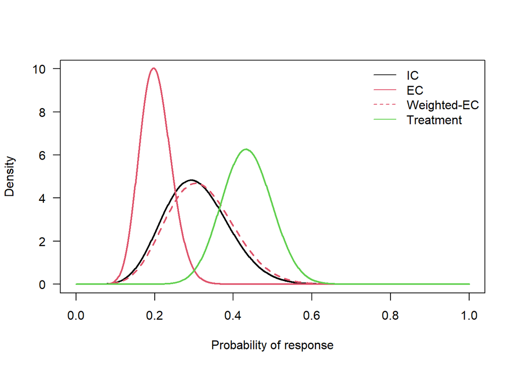

```r
p <- seq(0, 1, 0.001)
den_ec <- dbeta(p, 0.5+sum(EC$response), 0.5+nrow(EC)-sum(EC$response))
den_wec <- dbeta(p, 0.5+EC_wy, 0.5+EC_wn-EC_wy)
den_ic <- dbeta(p, 0.5+IC_y, 0.5+IC_n-IC_y)
den_trt <- dbeta(p, 0.5+IT_y, 0.5+IT_n-IT_y)

par(mfrow = c(1, 1))
plot(p, den_ic, col = 1, type = "l", ylim = c(0, 10), las = 1, lwd = 2,
     xlab = "Probability of response", ylab = "Density")
lines(p, den_ec, col = 2, lwd = 2)
lines(p, den_wec, col = 2, lty = 2, lwd = 2)
lines(p, den_trt, col = 3, lwd = 2)

legend("topright", lty = c(1, 1, 2, 1), col = c(1, 2, 2, 3),
       c("IC", "EC", "Weighted-EC", "Treatment"), bty = "n")
```

Evaluate the similarity in outcome distributions between IC and EC:

```r
prior_delta <- 0
fit0 <- set.mem.prior(num_study = 2, delta = prior_delta)
fit0$prior
```

```
## [1] 0.5 0.5
```

```r
mem_fit <- update.part.bin(x = c(IC_y, EC_wy),
                       n = c(IC_n, EC_wn),
                       prior_part = fit0$prior,
                       part = fit0$part)

mem_fit$post_sim
```

```
## [1] 0.7737645
```

Borrow external data according to the similarity between the outcome distribution of weighted-EC and IC. The number of responders we borrow from EC is

```r
EC_wy*mem_fit$post_part[1]
```

```
##          [,1]
## [1,] 6.941174
```

The number of patients we borrow from EC is

```r
EC_wn*mem_fit$post_part[1]
```

```
## [1] 22.28917
```

```r
#hybrid control trial based on MEM
hc_mem <- bayes.two.prop(y0 = IC_y + EC_wy*mem_fit$post_part[1],
                      n0 = IC_n + EC_wn*mem_fit$post_part[1],
                      y1 = IT_y, n1 = IT_n,
                      prior0 = c(0.5, 0.5),
                      prior1 = c(0.5, 0.5))


IN_test <- bayes.two.prop(y0 = IC_y, n0 = IC_n,
               y1 = IT_y, n1 = IT_n,
               prior0 = c(0.5, 0.5),
               prior1 = c(0.5, 0.5))

posterior_summary <- rbind(c(hc_mem$est, hc_mem$ci, hc_mem$pp), c(IN_test$est, IN_test$ci, IN_test$pp))
rownames(posterior_summary) <- c("PW-MEM", "IN_test")
colnames(posterior_summary) <- c("Median", "2.5%CI", "97.5%CI", "PP")

round(posterior_summary, 3) %>%
  kbl(caption = "Posterior summary for the difference in probability of responese") %>%
  kable_classic(full_width = F, html_font = "Cambria") %>%
  footnote(general = "PW-MEM: analysis based on the hybrid control constructed using MEM and propensity score weighting;
           IN_test: analysis based on the internal control without borrowing from EC;
           PP: posterior probability of the treatment arm having a higher probability of response")
```

Posterior summary for the difference in probability of responese

|  | Median | 2.5%CI | 97.5%CI | PP |
| --- | --- | --- | --- | --- |
| PW-MEM | 0.126 | -0.048 | 0.294 | 0.92 |
| IN_test | 0.128 | -0.078 | 0.325 | 0.89 |

Note:  
PW-MEM: analysis based on the hybrid control constructed using MEM and propensity score weighting; IN_test: analysis based on the internal control without borrowing from EC; PP: posterior probability of the treatment arm having a higher probability of response